# Visualising RNA binding dynamics

Here we will visualise total and RNA-bound protein abundances across conditions.

Below we load the required packages and set a plotting theme.

```r
# load packages
library(tidyverse)
library(UniProt.ws)

# set up standardised plotting scheme
theme_set(theme_bw(base_size = 15) +
            theme(panel.grid.major=element_blank(),
                  panel.grid.minor=element_blank(),
                  aspect.ratio=1))

cbPalette <- c("#E69F00", "#56B4E9", "#009E73", "#F0E442",
               "#0072B2", "#D55E00", "#CC79A7", "#999999")
```

We start by reading in the data. Our input here is the protein-level quantification for the Nocodazole arrest/release experiment conducted for the OOPS NBT paper (https://www.nature.com/articles/s41587-018-0001-2). In this experiment, we wanted to assess changes in RNA binding in arrested/released cells. To do this, we quantified “total” protein abundance and RNA-bound (extracted by OOPS) protein abundance. The peptide-level abundances have been aggregated to protein level abundance and center-median normalised. Proteins with missing values have been removed. Only proteins quantified in both “total” and “OOPS” samples are included.

The input data here is identical to supplementary table 5 from the above paper.

```r
protein_quant_raw <- readxl::read_excel('../raw/ncbi_30607034_OOPS_NBT_table_S5.xlsx',
                                        sheet=3, skip=1, n_max=1917)
```

In order to plot a functional subset of proteins, we will use the UniProt pathway annotations.

Warning: This cell will take a few minutes to run the query on the Uniprot database…

```r
humanUP <- UniProt.ws(taxId=9606) # H.sapiens
protein_ids <- protein_quant_raw$master_protein

hsapiens.annot <- AnnotationDbi::select(
  humanUP,
  keys = protein_ids,
  columns = c("PATHWAY",  "PROTEIN-NAMES"),
  keystyle = "UNIPROTKB")
```

```
Uniprot limits queries with a large amount of keys. It's recommended that the select method be invoked with fewer than 100 keys or the query may fail.
Getting extra data for A0AVT1, A1L0T0, A1L390... (400 total)
Getting extra data for P22087, P22102, P22234... (400 total)
Getting extra data for P78371, P78406, P78417... (400 total)
Getting extra data for Q6ZSZ5, Q6ZUT6, Q712K3... (400 total)
Getting extra data for Q9H307, Q9H3N1, Q9H3P7... (316 total)
```

```r
hsapiens.pathway <-  hsapiens.annot %>% data.frame() %>%
  separate_rows(PATHWAY, sep="; ") %>% dplyr::select(UNIPROTKB, PROTEIN.NAMES, PATHWAY)
```

Identify the glycolysis proteins

```r
glycolysis_proteins <- hsapiens.pathway %>% filter(PATHWAY=='glycolysis')
glycolysis_proteins$cleaned_protein_name <- sapply(strsplit(glycolysis_proteins$PROTEIN.NAMES, split='\\('), '[[', 1)
```

Restructure the data and subset to the glycolysis proteins

```r
glycolysis_intensities <- protein_quant_raw %>%
  gather(key='sample', value='intensity', -master_protein) %>%
  merge(glycolysis_proteins, by.x='master_protein', by.y='UNIPROTKB') %>%
  separate(sample, into=c('timepoint', 'replicate', 'type'), remove=FALSE) %>%
  mutate(type=factor(type, levels=c('total', 'OOPS'))) %>%
  mutate(timepoint=factor(timepoint, levels=c('0h', '6h', '23h')))

glycolysis_intensities$type <- recode(glycolysis_intensities$type,  'OOPS'='RNA-bound', 'total'='Total')
```

Plot the glycolysis proteins

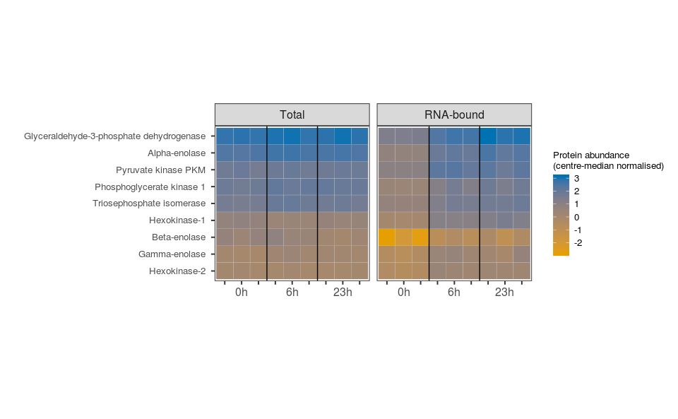

```r
protein_order <- glycolysis_intensities %>%
  group_by(cleaned_protein_name) %>% summarise(max_intensity=max(intensity)) %>%
  arrange(max_intensity) %>% pull(cleaned_protein_name)

p <- glycolysis_intensities %>%
  mutate(cleaned_protein_name=factor(cleaned_protein_name, levels=protein_order)) %>%
  ggplot(aes(interaction(replicate, timepoint), cleaned_protein_name, fill=intensity)) +
  geom_tile(colour='grey80', lwd=0.1) +
  facet_grid(.~type) +
  ylab('') + xlab('') +
  scale_x_discrete(labels=c('', '0h', '', '', '6h', '', '', '23h', '')) +
  geom_vline(xintercept=3.5) +
  geom_vline(xintercept=6.5) +
  scale_fill_gradient(low=cbPalette[1], high=cbPalette[5], name='Protein abundance\n(centre-median normalised)') +
  theme(axis.text.y=element_text(size=10), legend.title=element_text(size=10), legend.text=element_text(size=10))

print(p)
```

```r
ggsave('../results/plots/rna_binding_changes_heatmap.png', width=10, height=5)
ggsave('../results/plots/rna_binding_changes_heatmap.pdf', width=10, height=5)
```